# A Study on Severe Weather Events in USA

Wenhe ‘Wayne’ Ye

September 24, 2015

## Synopsis

#### 1.How to import the raw data?

##### -Downloading Data

##### -Caching Data

#### 2.How to clean up the raw data to get tidy data?

##### -Correcting Typos

##### -Unit Conversion

#### 3.How to summarize the data?

##### -Using dplyr package

#### 4.How to present the analysis and result?

##### -Genrating Tables and Barplots

## Data Processing

### 1.Downloading and importing

This procedure might take a few minutes for downloading and extracting data sets. Raw data stored as *raw_stormdata*

```r
rm(list=ls())
if(!dir.exists("./data")){
        dir.create("./data")
}
dataURL<-"https://d396qusza40orc.cloudfront.net/repdata%2Fdata%2FStormData.csv.bz2"
if(!file.exists("./data/Stormdata.csv.bz2")){
download.file(dataURL,"./data/Stormdata.csv.bz2")
}
raw_stormdata<-read.csv(bzfile("./data/Stormdata.csv.bz2"))
```

### 2.Cleaning up and summarizing

We first extract a few columns from the *raw_stormdata*. We are typically interested in variables with regard to either economic loss or life safety.

```r
library(dplyr)
my_stormdata<-select(raw_stormdata,EVTYPE,STATE,FATALITIES,INJURIES,PROPDMG,PROPDMGEXP,CROPDMG,CROPDMGEXP)
```

The recorded event type descriptions are messy. We first set them to uppercase and merge the names of similar events into their official categories. This procedure can be done iteratively to ensure the topmost events are recorded correctly. Here in this report, we do not fix all the typos since the some of these are really odd and may not cause a major deviation.

```r
my_stormdata<-mutate(my_stormdata,Event_Type=as.factor(toupper(as.character(EVTYPE)))) #set to uppercase
evt_factor_lvl<-levels(my_stormdata$Event_Type)
evt_factor_lvl[which(evt_factor_lvl=="TSTM WIND")]<-"THUNDERSTORM WIND"
evt_factor_lvl[which(evt_factor_lvl=="THUNDERSTORM WINDS")]<-"THUNDERSTORM WIND"
evt_factor_lvl[which(evt_factor_lvl=="WILD/FOREST FIRE")]<-"WILDFIRE"
evt_factor_lvl[which(evt_factor_lvl=="RIP CURRENTS")]<-"RIP CURRENT"
evt_factor_lvl[which(evt_factor_lvl=="HURRICANE")]<-"HURRICANE/TYPHOON"
levels(my_stormdata$Event_Type)<-evt_factor_lvl
```

In order to calculate the right loss data quoted in dollars, we clean up both the *PROPDMGEXP* and *CROPDMGEXP* data and assign a vector *Exp_vector_T* for transform the loss data into trillion dollars. The transformation will be carried out in the analyzing part for Q2.

```r
my_stormdata<-mutate(my_stormdata,PropDmgExp=as.factor(toupper(as.character(PROPDMGEXP))))
my_stormdata<-mutate(my_stormdata,CropDmgExp=as.factor(toupper(as.character(CROPDMGEXP))))
prop_fac_lvl<-levels(my_stormdata$PropDmgExp)
prop_fac_lvl[!prop_fac_lvl %in% c("B","M","K","H")]<-"D"
crop_fac_lvl<-levels(my_stormdata$CropDmgExp)
crop_fac_lvl[!crop_fac_lvl %in% c("B","M","K","H")]<-"D"
levels(my_stormdata$PropDmgExp)<- prop_fac_lvl
levels(my_stormdata$CropDmgExp)<- crop_fac_lvl
Exp_vector_T<-c("D"=0.001/1000000000,"H"=0.1/1000000000,"K"=1/1000000000,"M"=1/1000000,"B"=1/1000)
```

(**Q1 Analysis**)We grouped data by event types and calculate the both the total casualties and total fatalities. We saved the top 10 most harmful events in *my_cas_barplot_data*. A barplot will be generated from the resulted data.

```r
grouped_stormdata<-group_by(my_stormdata,Event_Type)
sum_cas_stormdata<-summarize(grouped_stormdata,CASUALTIES=sum(FATALITIES+INJURIES),TOTAL_INJURIES=sum(INJURIES),TOTAL_FATALITIES=sum(FATALITIES))
sum_cas_stormdata<-arrange(sum_cas_stormdata,desc(CASUALTIES))
sum_cas_stormdata<-mutate(sum_cas_stormdata,CASUALTIES_K=CASUALTIES/1000,TOTAL_FATALITIES_K=TOTAL_FATALITIES/1000,TOTAL_INJURIES_K=TOTAL_INJURIES/1000)
my_cas_barplot_data<-rbind(sum_cas_stormdata[1:10,]$TOTAL_FATALITIES_K,sum_cas_stormdata[1:10,]$TOTAL_INJURIES_K)
names(my_cas_barplot_data)<-as.character(sum_cas_stormdata[1:10,]$Event_Type)
```

(**Q2 Analysis**)We grouped data by event types and calculate the both the total property damage and crop damage. The actual loss in the unit of trillion dollars is calculated by the code below by looking up the vector *Exp_vector_T*. We shortlist the top 10 most dustructive events in *my_eco_barplot_data*. A barplot will be generated from the resulted data.

```r
sum_eco_stormdata<-summarize(grouped_stormdata,PROPERTY_LOSS=sum(PROPDMG*Exp_vector_T[PropDmgExp]),CROP_LOSS=sum(CROPDMG*Exp_vector_T[CropDmgExp]))
sum_eco_stormdata<-mutate(sum_eco_stormdata,PROPERTY_LOSS,CROP_LOSS_M=CROP_LOSS*1000,TOTAL_LOSS=PROPERTY_LOSS+CROP_LOSS)
sum_eco_stormdata<-arrange(sum_eco_stormdata,desc(TOTAL_LOSS))
my_eco_barplot_data<-rbind(sum_eco_stormdata[1:10,]$PROPERTY_LOSS,sum_eco_stormdata[1:10,]$CROP_LOSS)
names(my_eco_barplot_data)<-as.character(sum_eco_stormdata[1:10,]$Event_Type)
```

## Results

(**Anser to Q1**)  
Below is the top 10 harmful severe weather events across US.

```r
library(xtable)
report_cas_stormdata<-sum_cas_stormdata[1:10,]
xreport_cas<-xtable(select(report_cas_stormdata,Event_Type,CASUALTIES,TOTAL_FATALITIES,TOTAL_INJURIES),caption = "Top 10 harmful severe weather events across US.")
print.xtable(xreport_cas,type = "html")
```

Top 10 harmful severe weather events across US.

|  | Event_Type | CASUALTIES | TOTAL_FATALITIES | TOTAL_INJURIES |
| --- | --- | --- | --- | --- |
| 1 | TORNADO | 96979.00 | 5633.00 | 91346.00 |
| 2 | THUNDERSTORM WIND | 10054.00 | 701.00 | 9353.00 |
| 3 | EXCESSIVE HEAT | 8428.00 | 1903.00 | 6525.00 |
| 4 | FLOOD | 7259.00 | 470.00 | 6789.00 |
| 5 | LIGHTNING | 6046.00 | 816.00 | 5230.00 |
| 6 | HEAT | 3037.00 | 937.00 | 2100.00 |
| 7 | FLASH FLOOD | 2755.00 | 978.00 | 1777.00 |
| 8 | ICE STORM | 2064.00 | 89.00 | 1975.00 |
| 9 | WILDFIRE | 1543.00 | 87.00 | 1456.00 |
| 10 | WINTER STORM | 1527.00 | 206.00 | 1321.00 |

We genereate a barplot to have an overview of the result.

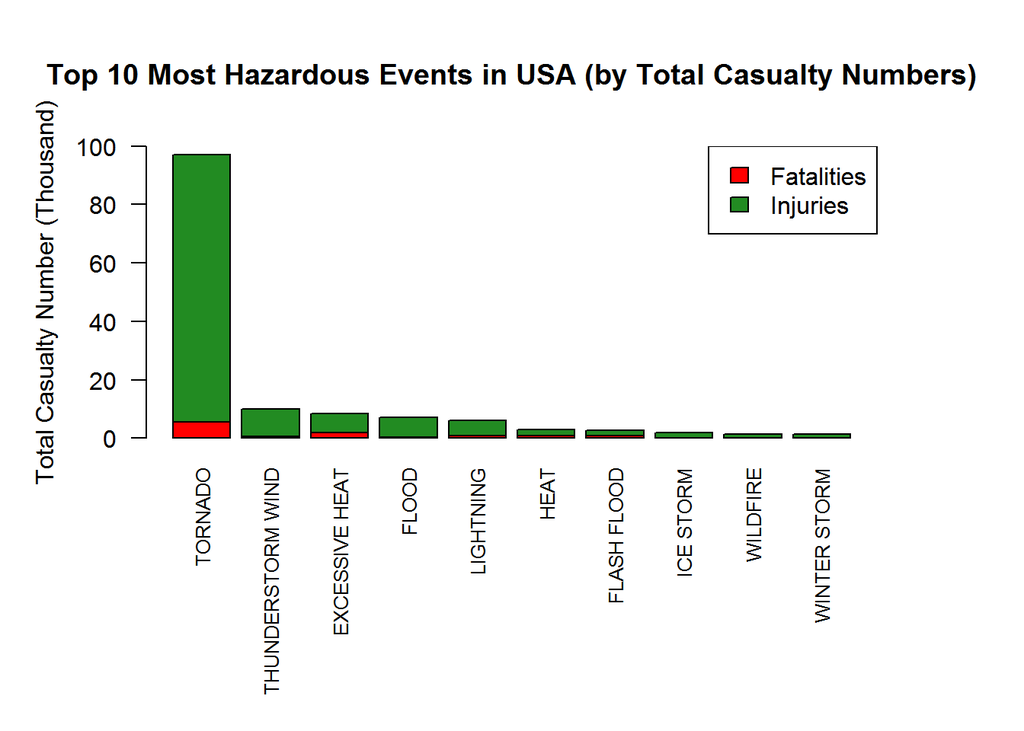

```r
par(mar=c(10,5,5,5))
barplot(my_cas_barplot_data,col=c("red","forestgreen"),names.arg = as.character(sum_cas_stormdata[1:10,]$Event_Type),las=2,ylim=c(0,100),cex.names=0.8)
title(main = "Top 10 Most Hazardous Events in USA (by Total Casualty Numbers)",ylab = "Total Casualty Number (Thousand)")
legend("topright",c("Fatalities","Injuries"),fill=c("red","forestgreen"))
```

**The tonados caused the most casualties in US according to the data. Which is far more harmful than the second and third ones. The reason might be tonado is usually highly unpredictable. However we shouldn’t overlook other severe weather events some of them may not be so unpredictable still precautions should be taken in advance.**

(**Anser to Q2**)  
Below is the top 10 most distructive severe weather events across US.

```r
report_eco_stormdata<-sum_eco_stormdata[1:10,]
xreport_eco<-xtable(select(report_eco_stormdata,Event_Type,PROPERTY_LOSS,CROP_LOSS_M,TOTAL_LOSS),caption="Top 10 most distructive severe weather events across US")
print.xtable(xreport_eco,type = "html")
```

Top 10 most distructive severe weather events across US

|  | Event_Type | PROPERTY_LOSS | CROP_LOSS_M | TOTAL_LOSS |
| --- | --- | --- | --- | --- |
| 1 | TORNADO | 51.64 | 0.41 | 51.64 |
| 2 | FLOOD | 22.16 | 5.66 | 22.16 |
| 3 | FLASH FLOOD | 15.14 | 1.42 | 15.14 |
| 4 | HAIL | 13.93 | 3.03 | 13.94 |
| 5 | HURRICANE/TYPHOON | 9.97 | 3.84 | 9.98 |
| 6 | THUNDERSTORM WIND | 9.70 | 1.16 | 9.71 |
| 7 | WILDFIRE | 5.23 | 0.40 | 5.23 |
| 8 | HIGH WIND | 3.97 | 0.64 | 3.97 |
| 9 | ICE STORM | 3.94 | 0.02 | 3.94 |
| 10 | TROPICAL STORM | 2.55 | 0.68 | 2.55 |

We genereate a barplot to have an overview of the result.

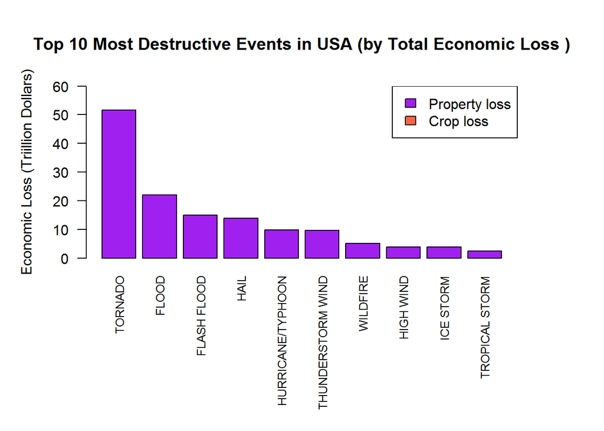

```r
par(mar=c(10,5,5,5))
barplot(my_eco_barplot_data,col=c("purple","tomato"),names.arg = as.character(sum_eco_stormdata[1:10,]$Event_Type),las=2,ylim=c(0,60),cex.names=0.8)
title(main = "Top 10 Most Destructive Events in USA (by Total Economic Loss )",ylab = "Economic Loss (Triillion Dollars)")
legend("topright",c("Property loss","Crop loss"),fill=c("purple","tomato"))
```